# CIS 544 - Homework Assignment 4

Yasshin Lozano. ylozano@stu.edu

# Homework Assignment 4

### — Problem 1 —

In this problem you will consider the `iris` dataset.

*Problem*:

- Build a *decision tree* to predict the class of flower (Iris Setosa, Iris Versicolor, Iris Virginica), where `Species` is a function of `Sepal.Width` and `Petal.Width`

```r
# Attach iris data set
library(rpart)
attach(iris)
# Print names of variables in the datase
names(iris)
```

```
[1] "Sepal.Length" "Sepal.Width"  "Petal.Length" "Petal.Width"
[5] "Species"
```

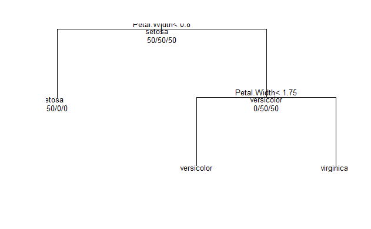

```r
# Fit decision tree
iris.fit <- rpart(Species~Sepal.Width+Petal.Width, method = "class",data = iris)
# Species as a function of Sepal.Width + Petal.Width
# Plot tree
plot(iris.fit,uniform = TRUE)
text(iris.fit,use.n=TRUE,all=TRUE,cex=.8)
```

- Create a scatter plot of `Sepal.Width` and `Petal.Width`. What is the relationship between this plot and the results obtained in the decision tree you created before?

The plot seperates the different species pretty well and matches the decision tree with regards to the splits.

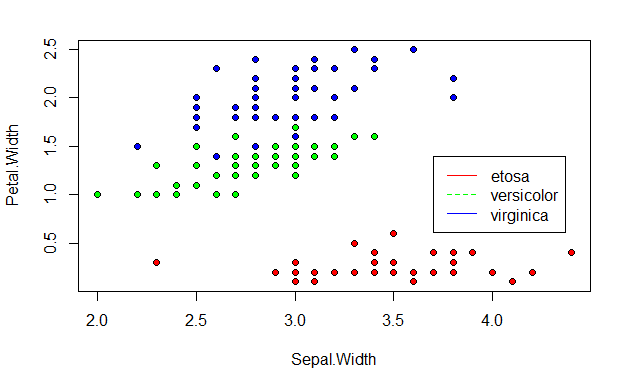

```r
# In order to create a plot with different colors for the
# different classes you can use the command below
plot(Sepal.Width,Petal.Width,pch=21,bg=c("red","green","blue")[unclass(Species)])
legend(3.7,1.4, legend=c("etosa", "versicolor","virginica"),
       col=c("red","green","blue"), lty=1:2, cex=1)
```

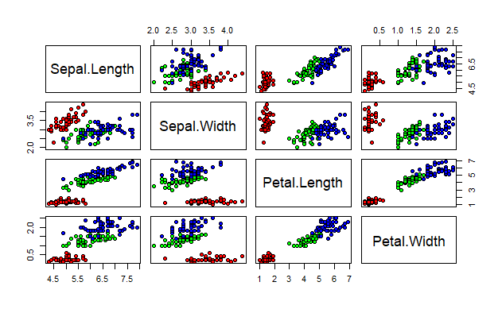

```r
pairs(iris[1:4],pch=21,bg=c("red","green","blue")[unclass(Species)])
```

- Build a **decision tree** where `Species` is a function of all variables `Sepal.Width`, `Petal.Width`, `Sepal.Length`, and `Sepal.Length`. Plot the tree. Comment on the misclassification rate in this new tree.

Based on the missclassification rate it correctly classified 50 setosa species. Versicolor and Virginica had a fairly good classification with only 1 false positive and 5 false negatives. The miss classification rate is 0.04 based on the confusion matrix and the cptable (Root node error=0.66667 * 0.06 error at 2nd split)

```r
library(rpart)#classification and regression trees
library(partykit)#treeplots
library(randomForest)#random forests
library(xgboost)#gradient boosting
library(caret)#tune hyper-parameters
library(InformationValue)
set.seed(305)
tree.leaf<-rpart(Species~., data = iris)
printcp(tree.leaf)
```

```
Classification tree:
rpart(formula = Species ~ ., data = iris)

Variables actually used in tree construction:
[1] Petal.Length Petal.Width

Root node error: 100/150 = 0.66667

n= 150

    CP nsplit rel error xerror     xstd
1 0.50      0      1.00   1.18 0.050173
2 0.44      1      0.50   0.71 0.061150
3 0.01      2      0.06   0.10 0.030551
```

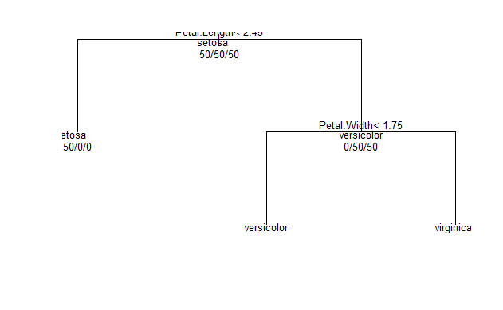

```r
plot(tree.leaf,uniform = TRUE)
text(tree.leaf,use.n=TRUE,all=TRUE,cex=.8)
```

```r
test.predict<-predict(tree.leaf,type="class")
table(iris$Species,test.predict)
```

```
            test.predict
             setosa versicolor virginica
  setosa         50          0         0
  versicolor      0         49         1
  virginica       0          5        45
```

### — Problem 2 —

Build a **random forest** classifier for the `Pima` diabetes data set.

```r
library(MASS)           #pima indian data
set.seed(123)
rf.pima<-randomForest(type~.,type="class",data = Pima.te)
rf.pima
```

```
Call:
 randomForest(formula = type ~ ., data = Pima.te, type = "class")
               Type of random forest: classification
                     Number of trees: 500
No. of variables tried at each split: 2

        OOB estimate of  error rate: 21.08%
Confusion matrix:
     No Yes class.error
No  198  25   0.1121076
Yes  45  64   0.4128440
```

The mean prediction error(OOB) for classifying type is 21.08% on each training sample. The randomForest classifies “No” better than “Yes”.

- Make sure to comment on your results.

### — Problem 3 —

You will need the `Carseats` data set from the `ISLR` package.

The following code construst the `High` variable for the purpose of *classification*.

```r
library(ISLR)
data(Carseats)
High <- with(Carseats, ifelse(Sales <= 8, "No", "Yes"))
Carseats <- data.frame(Carseats, High)
```

- Build a **decision tree** to classify whether `Carseat` sales in a store are high or not.

```r
Nosales<-Carseats[,-1]
carseat_tree<-rpart(High~., data = Nosales)
Nosales
```

[output not shown]

[output cut: 390 more lines]

- Create the plot of the decision tree and comment on your results.

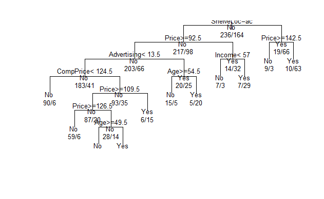

```r
plot(carseat_tree,uniform = TRUE)
text(carseat_tree,use.n=TRUE,all=TRUE,cex=.8)
```

```r
#The plot displays if the sales are high or not. The sales are categorized into No if the sales are less than 8 and Yes if more than 8. 236 of the sales were classified as no and 164 sales were classified as Yes. The sales of car seats are mostly not high so they should change how they market the product in order to classify more sales into being High.
```

You can use the code below to create a partition of the data:

```r
set.seed(217)
train <- sample(1:nrow(Nosales), 200)
Carseats.test <- Nosales[-train,]
High.test <- High[-train]
carseat_tree2<-rpart(High.test~., data = Carseats.test)
carseat.predict<-predict(carseat_tree2,type = "class",newdata=Carseats.test)
table(Carseats.test$High,carseat.predict   )
```

```
     carseat.predict
       No Yes
  No  119   0
  Yes   0  81
```